# Case Study: How can a Wellness Technology Company Play it Smart?

#### Obervations

- Ids 8877689391 and 8053475328 are consistently top performers when it comes to high activity, and total distance and steps
- Some users will have more than 1 sleep records per day and some significantly more than others

#### Opportunities

- Allow participants to see and compare profiles and statistics of the most active and high performing participants (with adherence to data sharing permissions and anonymity/privacy standards). Users could then copy or target similar statistics and activity levels to improve their own health and fitness goals.

###### Intensity per hour

```r
# Import & describe the data
hours = read.csv("clean_data/hr_merge.csv")
hours <- subset(hours, select = -X)

str(hours)
```

```
## 'data.frame':    22099 obs. of  6 variables:
##  $ Id              : num  1.5e+09 1.5e+09 1.5e+09 1.5e+09 1.5e+09 ...
##  $ ActivityHour    : chr  "2016-04-12 00:00:00" "2016-04-12 01:00:00" "2016-04-12 02:00:00" "2016-04-12 03:00:00" ...
##  $ Calories        : int  81 61 59 47 48 48 48 47 68 141 ...
##  $ TotalIntensity  : int  20 8 7 0 0 0 0 0 13 30 ...
##  $ AverageIntensity: num  0.333 0.133 0.117 0 0 ...
##  $ StepTotal       : int  373 160 151 0 0 0 0 0 250 1864 ...
```

```r
dim(hours)
```

```
## [1] 22099     6
```

```r
summary(hours)
```

```
##        Id            ActivityHour          Calories      TotalIntensity
##  Min.   :1.504e+09   Length:22099       Min.   : 42.00   Min.   :  0.00
##  1st Qu.:2.320e+09   Class :character   1st Qu.: 63.00   1st Qu.:  0.00
##  Median :4.445e+09   Mode  :character   Median : 83.00   Median :  3.00
##  Mean   :4.848e+09                      Mean   : 97.39   Mean   : 12.04
##  3rd Qu.:6.962e+09                      3rd Qu.:108.00   3rd Qu.: 16.00
##  Max.   :8.878e+09                      Max.   :948.00   Max.   :180.00
##  AverageIntensity   StepTotal
##  Min.   :0.0000   Min.   :    0.0
##  1st Qu.:0.0000   1st Qu.:    0.0
##  Median :0.0500   Median :   40.0
##  Mean   :0.2006   Mean   :  320.2
##  3rd Qu.:0.2667   3rd Qu.:  357.0
##  Max.   :3.0000   Max.   :10554.0
```

```r
print(paste0("Are there any NAs = ",any(is.na(hours))))
```

```
## [1] "Are there any NAs = FALSE"
```

```r
print(paste0("Number of unique Ids: " ,length(unique(hours$Id))))
```

```
## [1] "Number of unique Ids: 33"
```

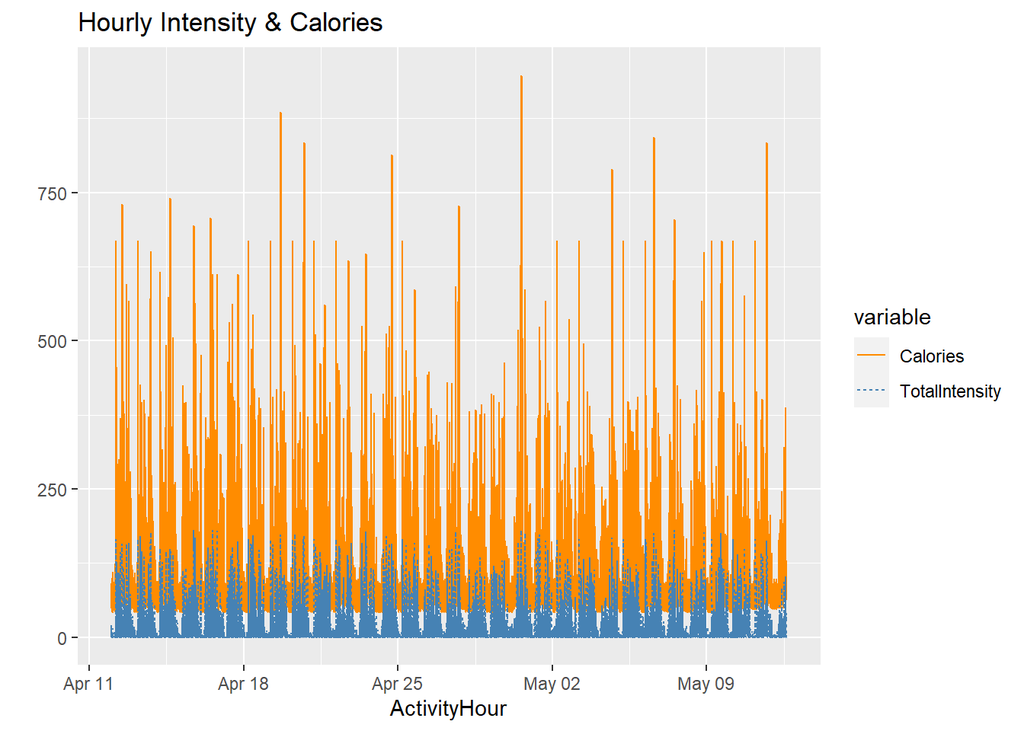

```r
# format date
hours$ActivityHour <- as.POSIXct(hours$ActivityHour, format= "%Y-%m-%d %H:%M:%S")
hours <- hours[order(hours$ActivityHour),]

# Extract hour from date/time
hours$Hour <- as.numeric(strftime(hours$ActivityHour, format="%H"))

chart <- hours %>%
  select(ActivityHour, Calories, TotalIntensity) %>%
  gather(key = "variable", value = "value", -ActivityHour)

ggplot(chart, aes(x = ActivityHour, y = value)) +
  geom_line(aes(color = variable, linetype = variable)) +
  labs(y="") +
  ggtitle("Hourly Intensity & Calories") +
  scale_color_manual(values = c("darkorange", "steelblue"))
```

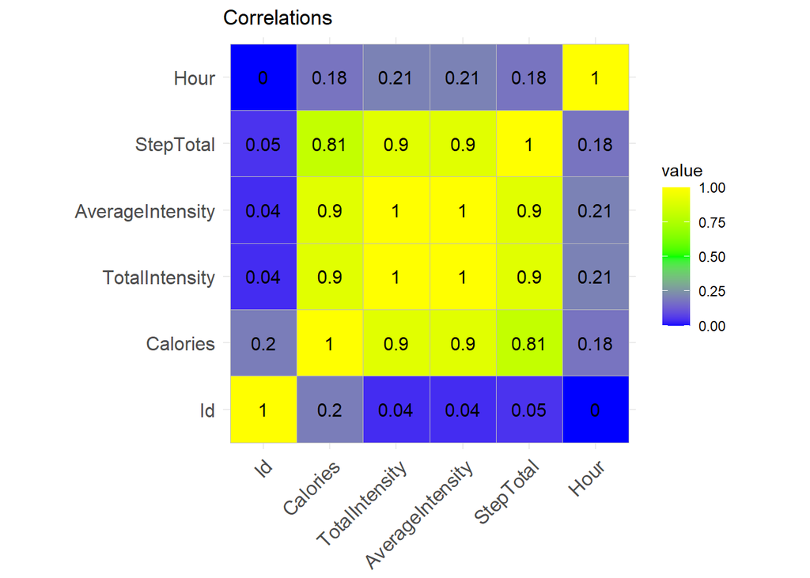

```r
# Extract numeric variables for correlation
hours_num <- hours[,sapply(hours, is.numeric)]

# Visualise the correlations
ggcorrplot(cor(hours_num), lab = TRUE) +
  labs(title='Correlations') +
  scale_fill_gradient2(limit = c(0,1), low = "blue", high =  "yellow", mid = "green", midpoint = 0.5)
```

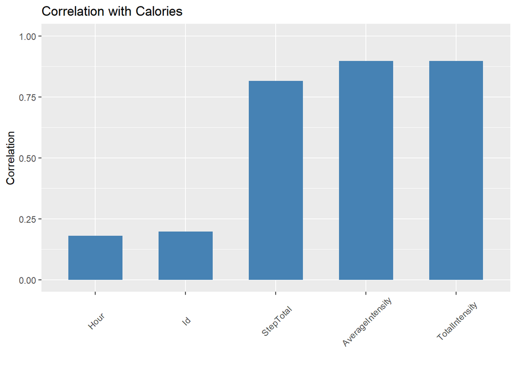

```r
# Visualise calories correlation

cor_hours <- cor(hours_num)
hrs_df <- data.frame(var = colnames(cor_hours),
                       calories = cor_hours[,2])
hrs_df <- hrs_df[order(hrs_df$calories, decreasing = FALSE),]
# geom_bar plots in alphabetical order. Factorise to current order.
hrs_df$var <- factor(hrs_df$var,
                       levels = hrs_df$var)
hrs_df <- head(hrs_df,-1) # remove last row (calories)

ggplot(hrs_df, aes(x=var, y = calories)) +
  geom_bar(stat="summary", fun=sum, width=0.6,fill="steelblue") +
  labs(y="Correlation", x="") +
  ggtitle("Correlation with Calories") +
  theme(legend.position="none") +
  theme(axis.text.x = element_text(angle = 45, vjust=+0.55)) +
  ylim(0, 1)
```

###### Group “Hours” into parts of the day

- Morning = 5am to 12pm
- Afternoon = 12pm to 5pm
- Evening = 5pm to 9pm
- Night = 9pm to 4am

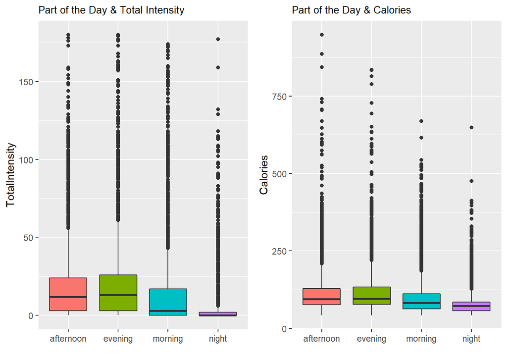

```r
# Group "Hours" into parts of the day
hours$PartOfDay <- with(hours,
                        ifelse((Hour >= 5 & Hour < 12), "morning",
                               ifelse((Hour >= 12 & Hour < 17), "afternoon",
                                      ifelse((Hour >=17 & Hour < 21), "evening",
                                             "night"))))

j1 <- ggplot(hours, aes(x=PartOfDay,y=TotalIntensity, fill=PartOfDay)) +
  geom_boxplot() +
  labs(title="Part of the Day & Total Intensity", x="") +
  theme(legend.position="none")+
  theme(plot.title = element_text(size = 10))


j2 <- ggplot(hours, aes(x=PartOfDay,y=Calories, fill=PartOfDay)) +
  geom_boxplot() +
  labs(title="Part of the Day & Calories", x="") +
  theme(legend.position="none") +
  theme(plot.title = element_text(size = 10))

grid.arrange(j1, j2, nrow=1, ncol=2)
```

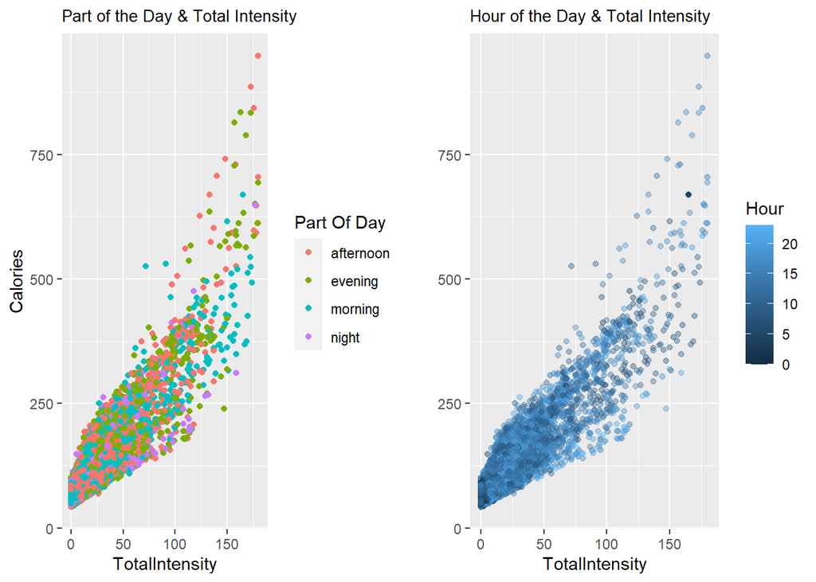

```r
# Scatter plot - intensity v calories
k1 <- ggplot(hours, aes(x = TotalIntensity, y = Calories)) +
  geom_point(aes(color = factor(PartOfDay))) +
  labs(color = "Part Of Day") +
  ggtitle("Part of the Day & Total Intensity") +
  theme(plot.title = element_text(size = 10))

# Boxplot - hours of day v calories
k2 <- ggplot(hours, aes(x = TotalIntensity, y = Calories)) +
  geom_point(alpha = 0.4,aes(color = Hour)) +
  labs(color = "Hour", y="") +
  ggtitle("Hour of the Day & Total Intensity") +
  theme(plot.title = element_text(size = 10))

grid.arrange(k1, k2, nrow=1, ncol=2)
```

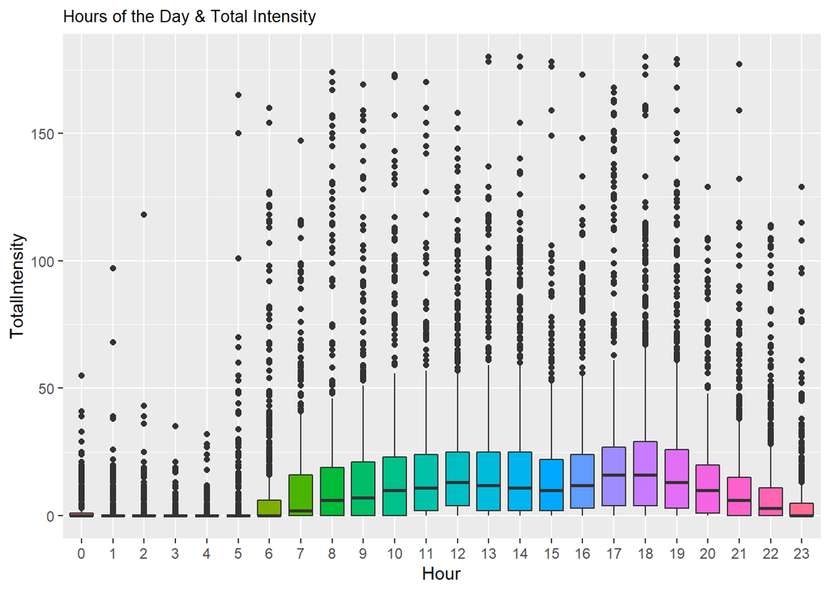

```r
ggplot(hours, aes(x=factor(Hour),y=TotalIntensity, fill=factor(Hour))) +
  geom_boxplot() +
  labs(title="Hours of the Day & Total Intensity", x="Hour") +
  theme(legend.position="none")+
  theme(plot.title = element_text(size = 10))
```

#### Observations:

- From the Correlation matrix we can see clear and understandable correlations between calories, intensity and steps
- TotalIntensity and AverageIntensity are completed correlated.
- The mean/median for intensity levels and calories burned, is highest in the evenings, closely followed by the afternoon.
- In the scatter plot you can see the relationship between intensity and calories, and also that most of the high intensity and calorie burn takes place around 6pm and this is confirmed in the boxplot.
- For the hourly distribution we can see that the median TotalIntensity is at at it’s highest around 5 and 6pm. Intensity reduces slowly up to 12pm.
- Although median is zero for the period between 12 pm and 5am, we can still see some activity around these hours. One participant achieves close to 125 total intensity at 2am.

#### Opportunities:

- Customers may appreciate a view of the high intensity and calorie burning periods during the day. They may see gaps in their own activity profile, allowing them to allocate more time at certain parts of the day to fitness activities. It can also provide information on when gyms and parks are likely to be at their busiest.

###### METs

Metabolic Equivalents

1 x MET = Energy you use when resting

4 x METs - exerting 4 times the energy than you would if you were sitting still

To get accurate MET values, divide by 10.

```r
# Import the data & Describe
mins = read.csv("clean_data/min_merge.csv")

# To get accurate MET values, divide by 10.
mins$METs <- mins$METs / 10

# Group "Hours" into parts of the day
mins$PartOfDay <- with(mins,
                        ifelse((Hour >= 5 & Hour < 12), "morning",
                               ifelse((Hour >= 12 & Hour < 17), "afternoon",
                                      ifelse((Hour >=17 & Hour < 21), "evening",
                                             "night"))))

str(mins)
```

```
## 'data.frame':    1325580 obs. of  11 variables:
##  $ ActivityMinute: chr  "2016-04-12 00:00:00" "2016-04-12 00:01:00" "2016-04-12 00:02:00" "2016-04-12 00:03:00" ...
##  $ Id            : num  1.5e+09 1.5e+09 1.5e+09 1.5e+09 1.5e+09 ...
##  $ Calories      : num  0.786 0.786 0.786 0.786 0.786 ...
##  $ Intensity     : int  0 0 0 0 0 0 0 0 0 0 ...
##  $ Steps         : int  0 0 0 0 0 0 0 0 0 0 ...
##  $ METs          : num  1 1 1 1 1 1.2 1.2 1.2 1.2 1.2 ...
##  $ Month         : int  4 4 4 4 4 4 4 4 4 4 ...
##  $ Day           : int  12 12 12 12 12 12 12 12 12 12 ...
##  $ Hour          : int  0 0 0 0 0 0 0 0 0 0 ...
##  $ Min           : int  0 1 2 3 4 5 6 7 8 9 ...
##  $ PartOfDay     : chr  "night" "night" "night" "night" ...
```

```r
dim(mins)
```

```
## [1] 1325580      11
```

```r
summary(mins)
```

```
##  ActivityMinute           Id               Calories         Intensity
##  Length:1325580     Min.   :1.504e+09   Min.   : 0.0000   Min.   :0.0000
##  Class :character   1st Qu.:2.320e+09   1st Qu.: 0.9357   1st Qu.:0.0000
##  Mode  :character   Median :4.445e+09   Median : 1.2176   Median :0.0000
##                     Mean   :4.848e+09   Mean   : 1.6231   Mean   :0.2006
##                     3rd Qu.:6.962e+09   3rd Qu.: 1.4327   3rd Qu.:0.0000
##                     Max.   :8.878e+09   Max.   :19.7499   Max.   :3.0000
##      Steps              METs            Month            Day
##  Min.   :  0.000   Min.   : 0.000   Min.   :4.000   Min.   : 1.00
##  1st Qu.:  0.000   1st Qu.: 1.000   1st Qu.:4.000   1st Qu.: 9.00
##  Median :  0.000   Median : 1.000   Median :4.000   Median :16.00
##  Mean   :  5.336   Mean   : 1.469   Mean   :4.339   Mean   :15.85
##  3rd Qu.:  0.000   3rd Qu.: 1.100   3rd Qu.:5.000   3rd Qu.:23.00
##  Max.   :220.000   Max.   :15.700   Max.   :5.000   Max.   :30.00
##       Hour            Min         PartOfDay
##  Min.   : 0.00   Min.   : 0.00   Length:1325580
##  1st Qu.: 5.00   1st Qu.:14.75   Class :character
##  Median :11.00   Median :29.50   Mode  :character
##  Mean   :11.42   Mean   :29.50
##  3rd Qu.:17.00   3rd Qu.:44.25
##  Max.   :23.00   Max.   :59.00
```

```r
print(paste0("Are there any NAs: " ,any(is.na(mins))))
```

```
## [1] "Are there any NAs: FALSE"
```

```r
print(paste0("Number of unique Ids: " ,length(unique(mins$Id))))
```

```
## [1] "Number of unique Ids: 33"
```

```r
# change to date format
mins$ActivityMinute <- as.POSIXct(mins$ActivityMinute, format="%Y-%m-%d")
# order the date
mins <-mins[order(mins$ActivityMinute),]

# Create a DayName column from the datetime
mins$DayName <- weekdays(mins$ActivityMinute)

# to allow us to view the correlation of dayName we can add dayName as a number
mins$DayOfWeek <- as.integer(factor(mins$DayName,levels=c("Tuesday","Wednesday","Thursday",
                                                                "Friday","Saturday","Sunday",
                                                                  "Monday"),ordered=TRUE))
```

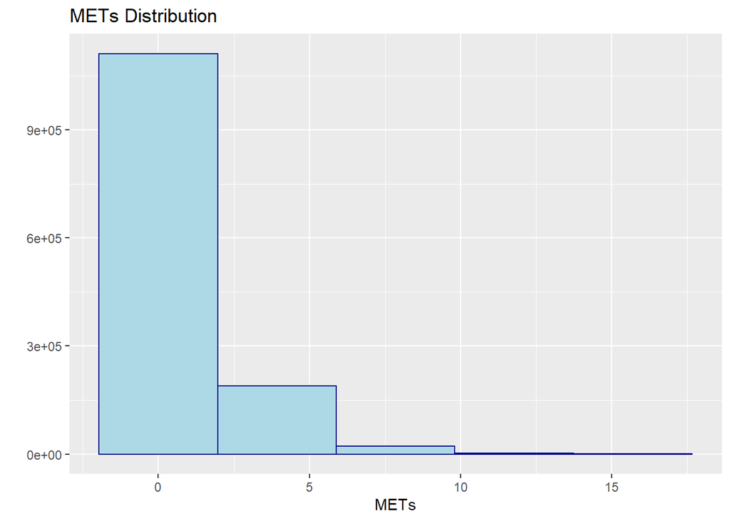

```r
# METs Distribution
ggplot(mins, aes(x=METs))+
  geom_histogram(color="darkblue", fill="lightblue", bins=5) +
  labs(title="METs Distribution", x="METs", y="")
```

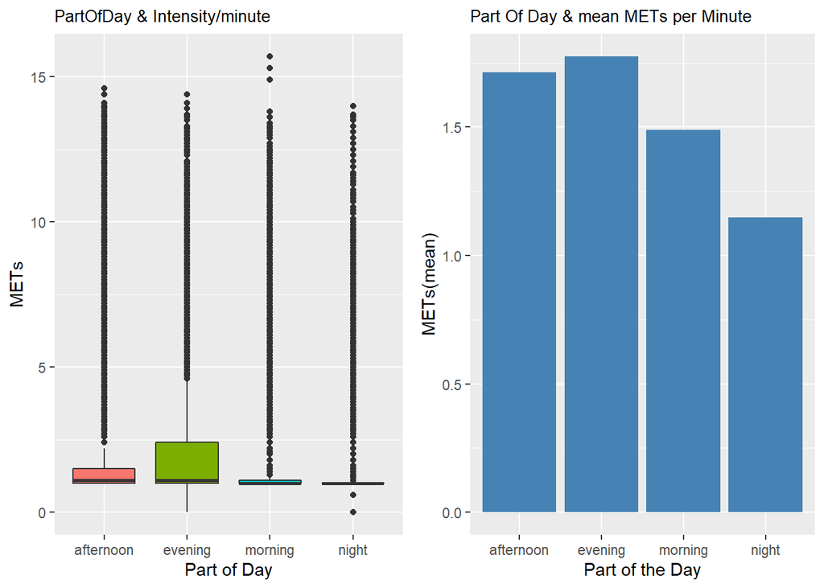

```r
# Calculate the mean & plot part of day & hour for METs
meanMET <- mins %>% group_by(Min, Hour) %>%
  summarise(METs = mean(METs))

meanMETs <- mins %>% group_by(PartOfDay) %>%
  summarise(METs = mean(METs))

l1 <- ggplot(mins, aes(x=factor(PartOfDay),y=METs, fill=factor(PartOfDay))) +
  geom_boxplot() +
  labs(title="PartOfDay & Intensity/minute", x="Part of Day") +
  theme(legend.position="none")+
  theme(plot.title = element_text(size = 10))

l2 <- ggplot(meanMETs, aes(x=PartOfDay, y = METs)) +
  geom_bar(stat="identity", fill="steelblue") +
  #geom_bar(stat="summary", fun=sum, fill="blue") +
  ggtitle("Part Of Day & mean METs per Minute") +
  labs(x="Part of the Day", y="METs(mean)") +
  theme(legend.position = "none") +
  theme(plot.title = element_text(size = 10))

grid.arrange(l1, l2, nrow=1, ncol=2)
```

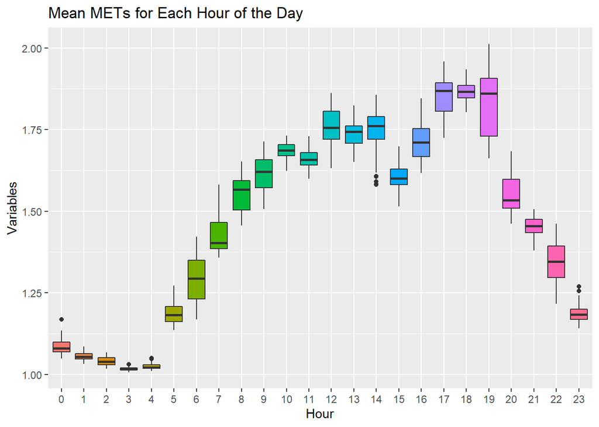

```r
ggplot(meanMET, aes(x=factor(Hour),y=METs, fill=factor(Hour))) +
  geom_boxplot() +
  labs(title="Mean METs for Each Hour of the Day", x="Hour", y="Variables") +
  theme(legend.position="none")
```

#### Observations:

- Mean METs follows a similar pattern to the Total Intensity for hour of the day. The hours 5pm - 7pm show the highest average MET. The variations are wider in METs (than Intensity) because MET is more sensitive - energy recorded when not resting
- We can see a clear dip in energy at 3pm before rising and peaking at 7pm. It then drops off during the later hours
- Evening activities have the highest mean METS per minute.

#### Opportunities:

- Using MET data, a MET feature could provide participants with a complete profile of their energy levels throughout the day (and across days). For example, they could use this to plan when to do work activities that require high concentration, or best time to plan their fitness activities.

###### Minutes Correlation

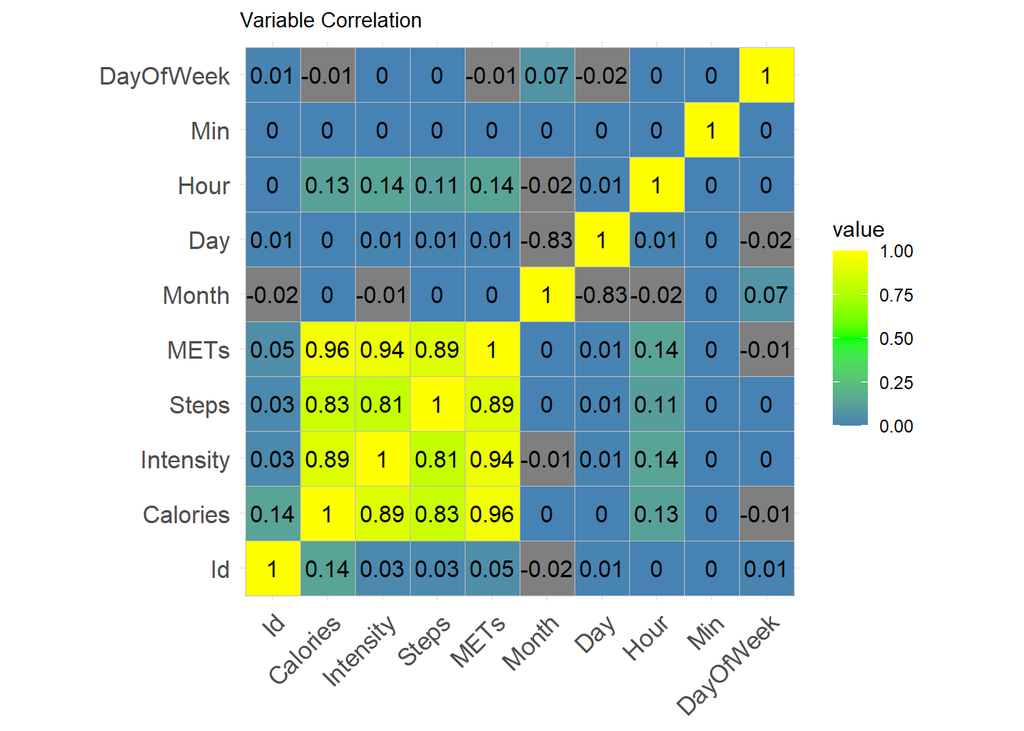

```r
# Minutes Correlation
mins_num <- mins[,sapply(mins, is.numeric)]

ggcorrplot(cor(mins_num), lab = TRUE) +
  labs(title='Variable Correlation') +
  theme(plot.title = element_text(size = 10)) +
  scale_fill_gradient2(limit = c(0,1), low = "steelblue", high =  "yellow", mid = "green", midpoint = 0.5)
```

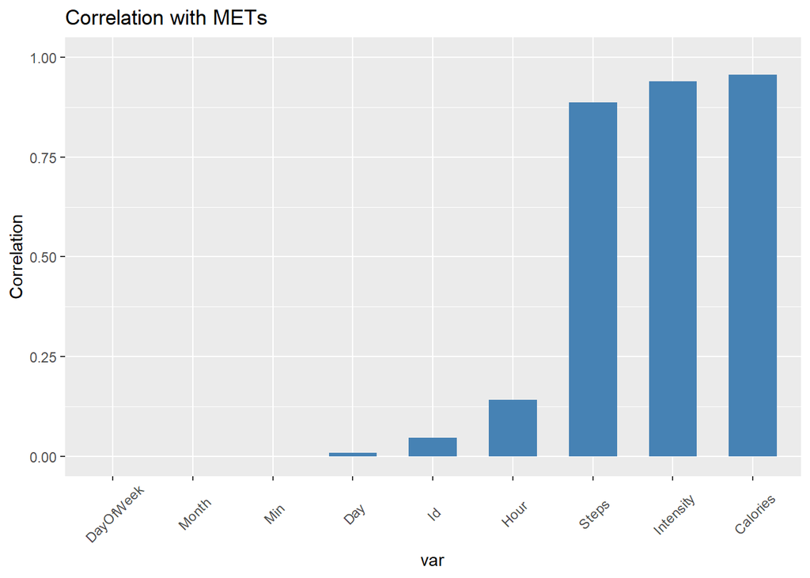

```r
# Correlaton with METs
cor_mins <- cor(mins_num)
mins_df <- data.frame(var = colnames(cor_mins),
                     METs = cor_mins[,5])
mins_df <- mins_df[order(mins_df$METs, decreasing = FALSE),]
# geom_bar plots in alphabetical order. Factorise to current order.
mins_df$var <- factor(mins_df$var,
                     levels = mins_df$var)
mins_df <- head(mins_df,-1) # remove last row (METs)

ggplot(mins_df, aes(x=var, y = METs)) +
  geom_bar(stat="summary", fun=sum, width=0.6,fill="steelblue") +
  labs(y="Correlation") +
  ggtitle("Correlation with METs") +
  theme(legend.position="none") +
  theme(axis.text.x = element_text(angle = 45, vjust=+0.55)) +
  ylim(0, 1)
```

#### Observations:

- Obviously METs is highly correlated with intensity and therefore calories. Mean METs follows a similar pattern to the Total Intensity for hour of the day. The hours 5pm - 7pm show the highest average MET. We can see a clear dip in energy at 3pm before rising and peaking at 7pm. It then drops off during the later hours.

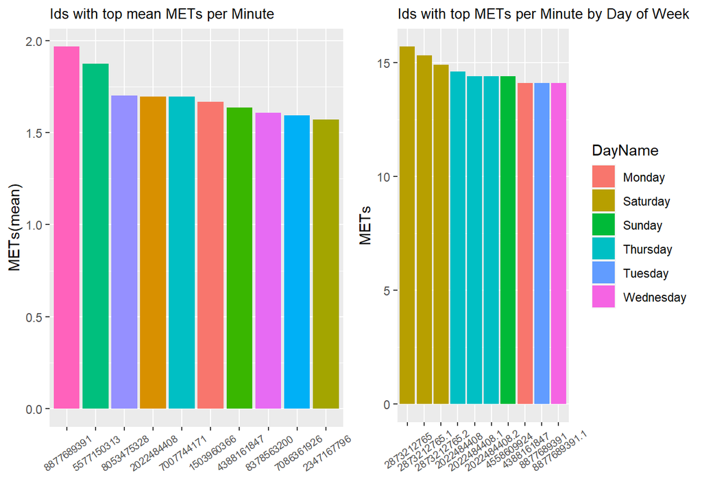

```r
# User & METs

meanIds <- mins %>% group_by(Id) %>%
  summarise(METs = mean(METs))
# order largest to smallest
meanIds <- meanIds[order(meanIds$METs, decreasing = TRUE),]
# top ten
meanIds <- head(meanIds, 10)

m1 <- ggplot(meanIds, aes(x=reorder(Id, -METs), y = METs, fill=factor(Id))) +
  geom_bar(stat="identity") +
  ggtitle("Ids with top mean METs per Minute") +
  labs(x="", y="METs(mean)") +
  theme(legend.position = "none") +
  theme(axis.text.x = element_text(size = 7, angle = 35, vjust=+0.55)) +
  theme(plot.title = element_text(size = 10))

sortMETs <- mins[order(mins$METs, decreasing = TRUE),]
sortMETs <- head(sortMETs,10)

# ggplot does not normally work well with duplicates because it cannot plot duplicate values
# along the x-axis without deploying some hack.
# To make duplicate factor levels unique in an R data frame, we can use make.unique function.

sortMETs <- within(sortMETs,Id<- ave(as.character(Id),FUN=make.unique))

m2 <- ggplot(sortMETs, aes(x=reorder(Id, -METs), y = METs, fill=DayName)) +
  geom_bar(stat="identity") +
  ggtitle("Ids with top METs per Minute by Day of Week") +
  labs(x="", y="METs") +
  #theme(legend.position = "none") +
  theme(axis.text.x = element_text(size = 7, angle = 35, vjust=+0.55)) +
  theme(plot.title = element_text(size = 10))

m3 <- ggplot(sortMETs, aes(x=reorder(Id, -METs), y = METs, fill=PartOfDay)) +
  geom_bar(stat="identity") +
  ggtitle("Ids with top METs per Minute by Day of Week") +
  labs(x="", y="METs") +
  #theme(legend.position = "none") +
  theme(axis.text.x = element_text(size = 7,angle = 35, vjust=+0.55)) +
  theme(plot.title = element_text(size = 10))

m4 <-ggplot(sortMETs, aes(x=reorder(Id, -METs), y = METs, fill=factor(Hour))) +
  geom_bar(stat="identity") +
  ggtitle("Ids with top METs per Minute by Hour of Day") +
  labs(x="", y="METs") +
  #theme(legend.position = "none") +
  theme(axis.text.x = element_text(size = 7, angle = 35, vjust=+0.55)) +
  theme(plot.title = element_text(size = 10))

grid.arrange(m1, m2, nrow=1, ncol=2)
```

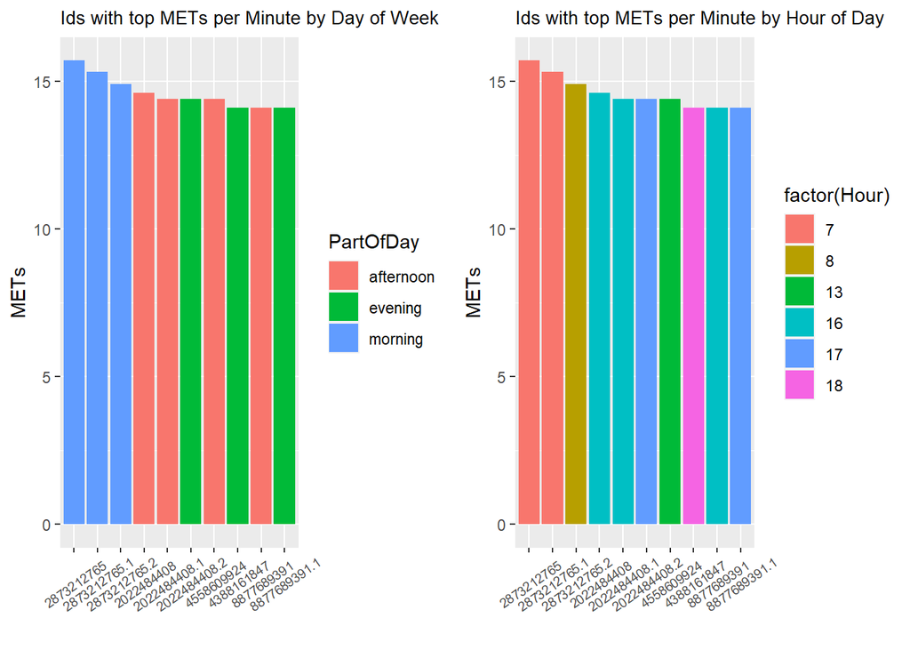

```r
grid.arrange(m3, m4, nrow=1, ncol=2)
```

#### Observations

- If you compare previous top Ids for very active minutes, distance and steps, and top Ids for METs, you will see similar Ids appearing, so the correlation between these factors are strong
- Highest mean METs per minute was on a Saturday in the morning at 7am. Users with the highest METs occur on a Saturday, Sunday and a Thursday. And this usually occurs in the morning and afternoon, around 7am to 8am and 4pm

###### Sleep Level and Heart Rate

```r
# import the data
sleepHR = read.csv("clean_data/min_sleep_HR_inner.csv")
sleepHR <- subset(sleepHR, select = -X)

str(sleepHR)
```

```
## 'data.frame':    76663 obs. of  12 variables:
##  $ ActivityMinute: chr  "2016-04-12 22:05:00" "2016-04-12 22:06:00" "2016-04-12 22:07:00" "2016-04-12 22:08:00" ...
##  $ Id            : num  2.35e+09 2.35e+09 2.35e+09 2.35e+09 2.35e+09 ...
##  $ Calories      : num  0.941 1.035 0.941 0.941 0.941 ...
##  $ Intensity     : int  0 0 0 0 0 0 0 0 0 0 ...
##  $ Steps         : int  0 0 0 0 0 0 0 0 0 0 ...
##  $ METs          : int  10 11 10 10 10 10 10 10 10 10 ...
##  $ Month         : int  4 4 4 4 4 4 4 4 4 4 ...
##  $ Day           : int  12 12 12 12 12 12 12 12 12 12 ...
##  $ Hour          : int  22 22 22 22 22 22 22 22 22 22 ...
##  $ Min           : int  5 6 7 8 9 10 11 12 13 14 ...
##  $ State         : int  3 3 2 1 1 2 1 1 1 1 ...
##  $ meanHR        : num  76.7 76.7 80.2 80.4 79.7 ...
```

```r
dim(sleepHR)
```

```
## [1] 76663    12
```

```r
summary(sleepHR)
```

```
##  ActivityMinute           Id               Calories         Intensity
##  Length:76663       Min.   :2.347e+09   Min.   : 0.8939   Min.   :0.00000
##  Class :character   1st Qu.:4.388e+09   1st Qu.: 0.9160   1st Qu.:0.00000
##  Mode  :character   Median :5.577e+09   Median : 1.0393   Median :0.00000
##                     Mean   :5.673e+09   Mean   : 1.1124   Mean   :0.01276
##                     3rd Qu.:6.962e+09   3rd Qu.: 1.2637   3rd Qu.:0.00000
##                     Max.   :8.792e+09   Max.   :12.3786   Max.   :3.00000
##      Steps              METs           Month            Day
##  Min.   : 0.0000   Min.   :10.00   Min.   :4.000   Min.   : 1.00
##  1st Qu.: 0.0000   1st Qu.:10.00   1st Qu.:4.000   1st Qu.: 9.00
##  Median : 0.0000   Median :10.00   Median :4.000   Median :16.00
##  Mean   : 0.1269   Mean   :10.33   Mean   :4.328   Mean   :16.07
##  3rd Qu.: 0.0000   3rd Qu.:10.00   3rd Qu.:5.000   3rd Qu.:23.00
##  Max.   :54.0000   Max.   :90.00   Max.   :5.000   Max.   :30.00
##       Hour            Min            State           meanHR
##  Min.   : 0.00   Min.   : 0.00   Min.   :1.000   Min.   : 39.40
##  1st Qu.: 2.00   1st Qu.:15.00   1st Qu.:1.000   1st Qu.: 55.80
##  Median : 4.00   Median :30.00   Median :1.000   Median : 60.83
##  Mean   : 6.15   Mean   :29.52   Mean   :1.071   Mean   : 61.15
##  3rd Qu.: 6.00   3rd Qu.:44.00   3rd Qu.:1.000   3rd Qu.: 65.50
##  Max.   :23.00   Max.   :59.00   Max.   :3.000   Max.   :138.00
```

```r
print(paste0("Are there any NAs: " ,any(is.na(sleepHR))))
```

```
## [1] "Are there any NAs: FALSE"
```

```r
print(paste0("Number of unique Ids: " ,length(unique(sleepHR$Id))))
```

```
## [1] "Number of unique Ids: 11"
```

###### Format data, create day name & rename state variable

```r
# change to date format
sleepHR$ActivityMinute <- as.POSIXct(sleepHR$ActivityMinute, format="%Y-%m-%d")
# order the date
sleepHR <-sleepHR[order(sleepHR$ActivityMinute),]

# Create a DayName column from the datetime
sleepHR$DayName <- weekdays(sleepHR$ActivityMinute)

# to allow us to view the correlation of dayName we can add dayName as a number
sleepHR$DayOfWeek <- as.integer(factor(sleepHR$DayName,
                                       levels=c("Tuesday","Wednesday",
                                                                "Thursday",
                                                                "Friday","Saturday","Sunday",
                                                                "Monday"),ordered=TRUE))

# To get accurate MET values, divide by 10.
sleepHR$METs <- sleepHR$METs / 10
# Group "Hours" into parts of the day
sleepHR$PartOfDay <- with(sleepHR,
                       ifelse((Hour >= 5 & Hour < 12), "morning",
                              ifelse((Hour >= 12 & Hour < 17), "afternoon",
                                     ifelse((Hour >=17 & Hour < 21), "evening",
                                            "night"))))
# Rename "State" to "SleepLevel"
sleepHR <- sleepHR %>%
  rename(SleepLevel = State)
print(paste0("Intensity Levels: " ,unique(sleepHR$Intensity)))
```

```
## [1] "Intensity Levels: 0" "Intensity Levels: 1" "Intensity Levels: 2"
## [4] "Intensity Levels: 3"
```

```r
print(paste0("Sleep Levels: " ,unique(sleepHR$SleepLevel)))
```

```
## [1] "Sleep Levels: 3" "Sleep Levels: 2" "Sleep Levels: 1"
```

Note:

Intensity = 0:Sedentary, 1:Light, 2:Moderate, 3:Very Active

Sleep Level = 1:asleep, 2:restless, 3:awake

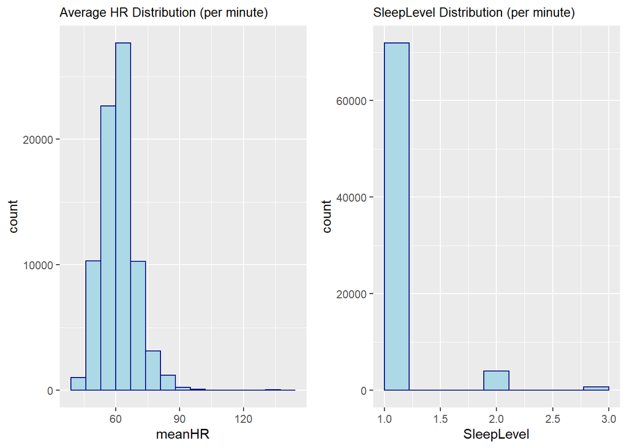

```r
# plot HR distribution
n1 <- ggplot(sleepHR)+
  geom_histogram(aes(x=meanHR), color="darkblue", fill="lightblue", bins=15) +
  labs(title="Average HR Distribution (per minute)", x="meanHR") +
  theme(plot.title = element_text(size = 10))

# plot Sleep Level distribution
n2 <- ggplot(sleepHR)+
  geom_histogram(aes(x=SleepLevel), color="darkblue", fill="lightblue", bins=10) +
  labs(title="SleepLevel Distribution (per minute)", x="SleepLevel") +
  theme(plot.title = element_text(size = 10))

grid.arrange(n1, n2, nrow=1, ncol=2)
```

###### Sleep Level Correlations

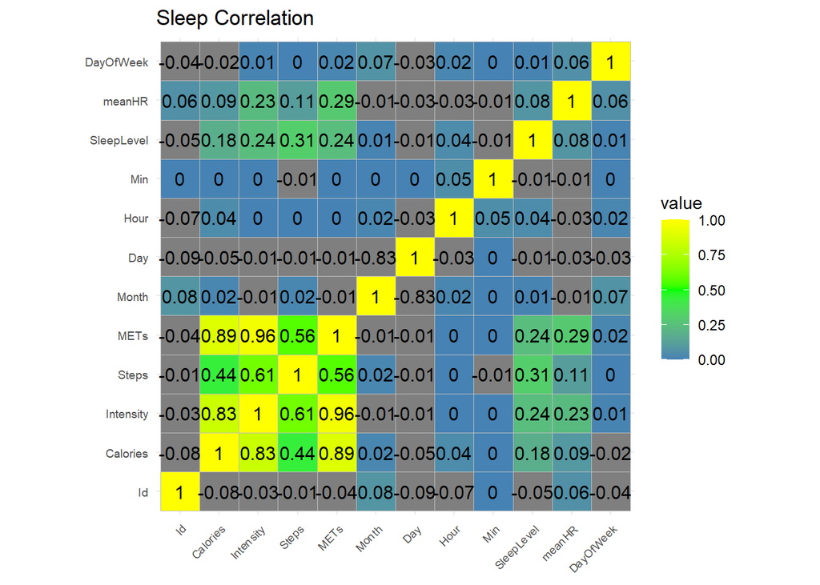

```r
sleepHR_num <- sleepHR[,sapply(sleepHR, is.numeric)]

ggcorrplot(cor(sleepHR_num), lab = TRUE, tl.cex = 7) +
  labs(title='Sleep Correlation') +
  scale_fill_gradient2(limit = c(0,1), low = "steelblue", high =  "yellow", mid = "green", midpoint = 0.5)
```

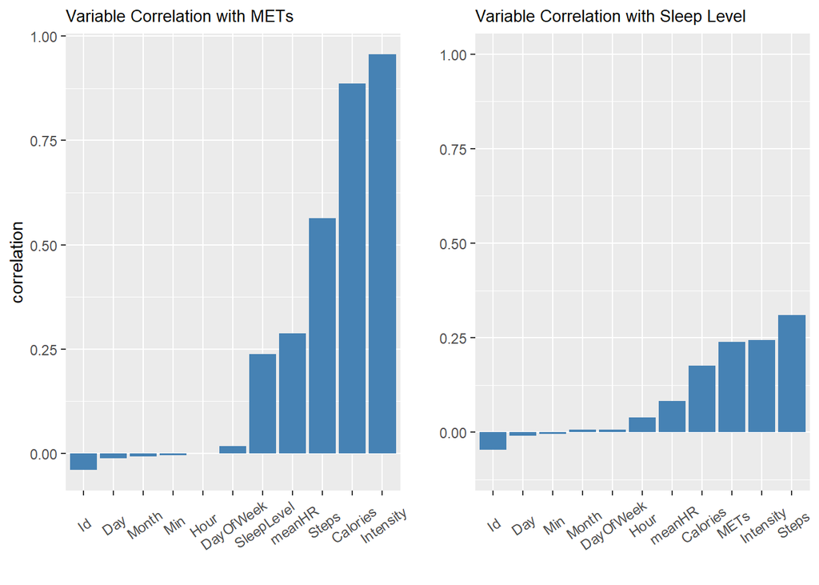

```r
sleep_corr <- cor(sleepHR_num)

# Correlation with METs
sleep_cor_df <- data.frame(var = colnames(sleep_corr), METs = sleep_corr[,5])
sleep_cor_df <- sleep_cor_df[order(sleep_cor_df$METs, decreasing=FALSE),]
# geom_bar plots in alphabetical order so we factorise to current order
sleep_cor_df$var <- factor(sleep_cor_df$var, levels = sleep_cor_df$var)
sleep_cor_df <- head(sleep_cor_df,-1)

# Correlation with Sleep Level
sleep_cor_df2 <- data.frame(var = colnames(sleep_corr), SleepLevel = sleep_corr[,10])
sleep_cor_df2 <- sleep_cor_df2[order(sleep_cor_df2$SleepLevel, decreasing=FALSE),]
# geom_bar plots in alphabetical order so we factorise to current order
sleep_cor_df2$var <- factor(sleep_cor_df2$var, levels = sleep_cor_df2$var)
sleep_cor_df2 <- head(sleep_cor_df2,-1)

# Correlation with Heart Rate
sleep_cor_df3 <- data.frame(var = colnames(sleep_corr), meanHR = sleep_corr[,11])
sleep_cor_df3 <- sleep_cor_df3[order(sleep_cor_df3$meanHR, decreasing=FALSE),]
# geom_bar plots in alphabetical order so we factorise to current order
sleep_cor_df3$var <- factor(sleep_cor_df3$var, levels = sleep_cor_df3$var)
sleep_cor_df3 <- head(sleep_cor_df3,-1)

O1 = ggplot(sleep_cor_df, aes(x=var, y = METs)) +
  geom_bar(stat="identity", fill="steelblue") +
  labs(y="correlation", x="") +
  ggtitle("Variable Correlation with METs") +
  theme(axis.text.x = element_text(angle = 35, vjust=+0.55)) +
  theme(plot.title = element_text(size = 10))

O2 <- ggplot(sleep_cor_df2, aes(x=var, y = SleepLevel)) +
  geom_bar(stat="identity", fill="steelblue") +
  labs(y="", x="") +
  ggtitle("Variable Correlation with Sleep Level") +
  ylim(-0.1,1) +
  theme(axis.text.x = element_text(angle = 35, vjust=+0.55)) +
  theme(plot.title = element_text(size = 10))

O3 <- ggplot(sleep_cor_df3, aes(x=var, y = meanHR)) +
  geom_bar(stat="identity", fill="steelblue") +
  labs(y="correlation", x="") +
  ggtitle("Variable Correlation with Heart Rate") +
  ylim(-0.1,1) +
  theme(axis.text.x = element_text(angle = 35, vjust=+0.55)) +
  theme(plot.title = element_text(size = 10))

O4 <- ggplot(sleepHR, aes(x = Intensity, y = METs)) +
  geom_point(alpha = 0.4,aes()) +
  labs(y="METs") +
  ggtitle("Intensity Level & METs Correlation") +
  theme(plot.title = element_text(size = 10))

grid.arrange(O1, O2, nrow=1, ncol=2)
```

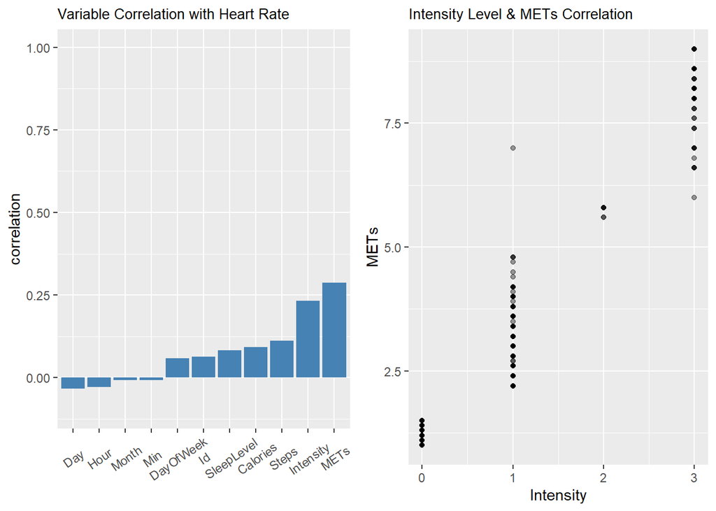

```r
grid.arrange(O3, O4, nrow=1, ncol=2)
```

###### Heart Rate Analysis

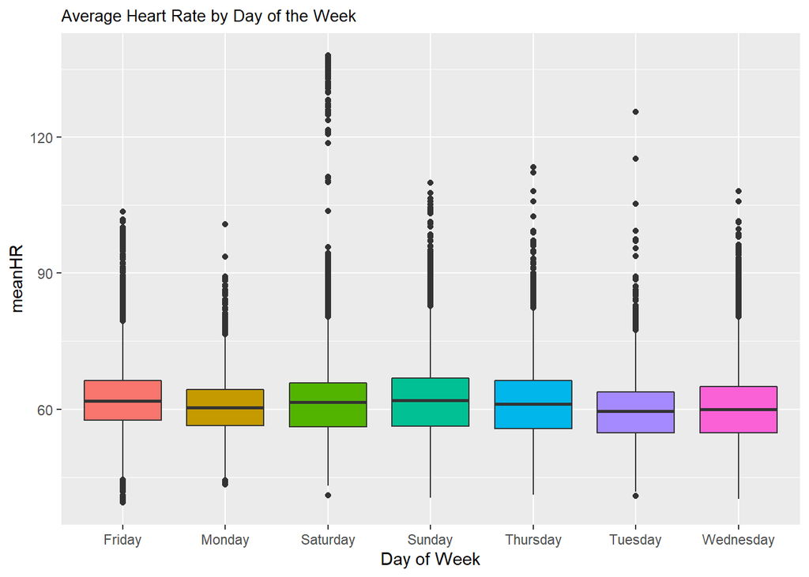

```r
p1 <- ggplot(sleepHR, aes(x=factor(DayName),y=meanHR, fill=factor(DayName))) +
  geom_boxplot() +
  labs(title="Average Heart Rate by Day of the Week", x="Day of Week") +
  theme(legend.position="none") +
  theme(plot.title = element_text(size = 10))

p2 <- ggplot(sleepHR, aes(x=factor(DayName),y=meanHR, fill=factor(PartOfDay))) +
  geom_boxplot() +
  labs(title="Average Heart Rate by PartOfDay", x="Day of Week") +
  theme(plot.title = element_text(size = 10))

p3 <- ggplot(sleepHR, aes(x = Intensity, y = meanHR)) +
  geom_point(alpha = 0.4,aes()) +
  labs(y="Mean Heart Rate") +
  ggtitle("Correlation for Average Heart Rate and Intensity") +
  geom_smooth(method='lm', formula= y~x) +
  theme(plot.title = element_text(size = 10))

grid.arrange(p1, nrow=1, ncol=1)
```

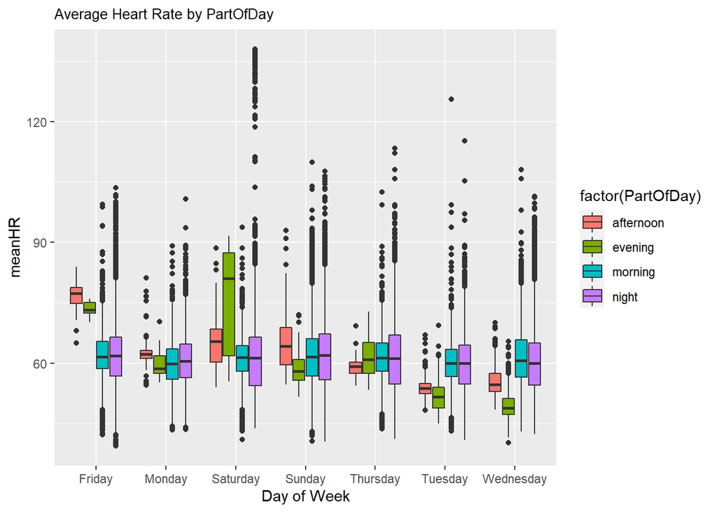

```r
grid.arrange(p2, nrow=1, ncol=1)
```

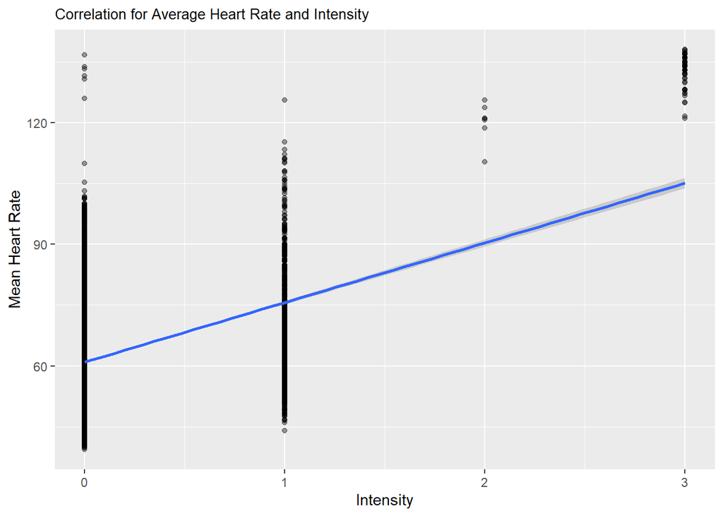

```r
grid.arrange(p3, nrow=1, ncol=1)
```

#### Observations:

- There are only 11 Users with Heart Rate data which is a very small sample size
- Average Heart Rate is slightly positive correlated with METs and Intensity Level.
- There appears to be some correlation between Sleep Level and the number of steps, and a slight correlation with Sleep Level and Intensity and METs.
- There is high positive correlation between Intensity Level and METs (and calories burned).
- Higher average heart rates are recorded on a Saturday, mostly during the evening but quite a few on a Saturday night.
- The lowest Heart Rates occur on a Wednesday evening

#### Opportunities:

- Keeping track of your heart rate can give you insight into your fitness level, heart health and emotional health. Heart Rates over time can give users insights into when (days of the week and time of the day) their heart rates are rising and falling and if these variations are a result of normal activities, exercise, or stress.

Note:

Intensity = 0:Sedentary, 1:Light, 2:Moderate, 3:Very Active

Sleep Level = 1:asleep, 2:restless, 3:awake

###### NOTE: When analysing this data it was noted that some days of the week have more records than others. Therefore, when analysing over time, especially patterns over days of the week, to deal with unbalanced data, it’s probably best to use percentages rather than total time.

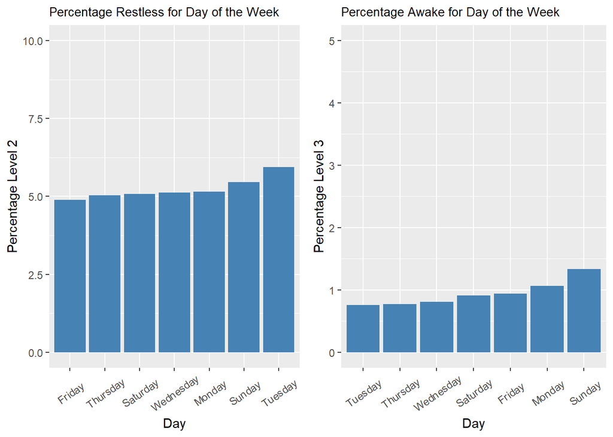

```r
# Which day has the largest restless percentage of sleep
dayList <- unique(sleepHR$DayName)
# dayList <- "Tuesday"
ls <- list()
for (day in dayList) {
  x <- sleepHR[sleepHR$DayName == day,]
  y <- x[x$SleepLevel == 2,]
  z <- nrow(y)/nrow(x)
  ls <- append(ls,z)
}
ls <- matrix(unlist(ls))
ls_df <- data.frame(dayList)
ls_df$Level2 <- ls
ls_df <- ls_df[order(ls_df$Level2, decreasing=FALSE),]
ls_df$dayList <- factor(ls_df$dayList, levels = ls_df$dayList)

q1 <- ggplot(ls_df, aes(x=dayList, y = (Level2*100))) +
  geom_bar(stat="identity", fill="steelblue") +
  labs(y="Percentage Level 2", , x="Day") +
  ggtitle("Percentage Restless for Day of the Week") +
  ylim(0,10) +
  theme(axis.text.x = element_text(angle = 35, vjust=+0.55)) +
  theme(plot.title = element_text(size = 10))

# Which day has the largest awake level percentage of sleep periods
ls2 <- list()
for (day in dayList) {
  x <- sleepHR[sleepHR$DayName == day,]
  y <- x[x$SleepLevel == 3,]
  z <- nrow(y)/nrow(x)
  ls2 <- append(ls2,z)
}

ls2 <- matrix(unlist(ls2))
ls2_df <- data.frame(dayList)
ls2_df$Level <- ls2
ls2_df <- ls2_df[order(ls2_df$Level, decreasing=FALSE),]
ls2_df$dayList <- factor(ls2_df$dayList, levels = ls2_df$dayList)

q2 <- ggplot(ls2_df, aes(x=dayList, y = (Level*100))) +
  geom_bar(stat="identity", fill="steelblue") +
  labs(y="Percentage Level 3", , x="Day") +
  ggtitle("Percentage Awake for Day of the Week") +
  ylim(0,5) +
  theme(axis.text.x = element_text(angle = 35, vjust=+0.55)) +
  theme(plot.title = element_text(size = 10))

# Which hour of the day has the largest restless percentage of sleep
hourList <- unique(sleepHR$Hour)
# dayList <- "Tuesday"
ls3 <- list()
for (hour in hourList) {
  x <- sleepHR[sleepHR$Hour == hour,]
  y <- x[x$SleepLevel == 2,]
  z <- nrow(y)/nrow(x)
  ls3 <- append(ls3,z)
}

ls3 <- matrix(unlist(ls3))
ls3_df <- data.frame(hourList)
ls3_df$Level <- ls3
ls3_df <- ls3_df[order(ls3_df$Level, decreasing=FALSE),]
ls3_df$hourList <- factor(ls3_df$hourList, levels = ls3_df$hourList)

q3 <- ggplot(ls3_df, aes(x=hourList, y = (Level*100))) +
  geom_bar(stat="identity", fill="steelblue") +
  labs(y="Percentage Level 2", x="Hour") +
  ggtitle("Percentage Restless for Hour of Day") +
  ylim(0,20) +
  theme(axis.text.x = element_text(angle = 35, vjust=+0.55)) +
  theme(plot.title = element_text(size = 10))

# Which hour of the day has the largest awake percentage of sleep
ls4 <- list()
for (hour in hourList) {
  x <- sleepHR[sleepHR$Hour == hour,]
  y <- x[x$SleepLevel == 3,]
  z <- nrow(y)/nrow(x)
  ls4 <- append(ls4,z)
}

ls4 <- matrix(unlist(ls4))
ls4_df <- data.frame(hourList)
ls4_df$Level <- ls4
ls4_df <- ls4_df[order(ls4_df$Level, decreasing=FALSE),]
ls4_df$hourList <- factor(ls4_df$hourList, levels = ls4_df$hourList)

q4 <- ggplot(ls4_df, aes(x=hourList, y = (Level*100))) +
  geom_bar(stat="identity", fill="steelblue") +
  labs(y="Percentage Level 3", x="Hour") +
  ggtitle("Percentage Awake for Hour of Day") +
  ylim(0,10) +
  theme(axis.text.x = element_text(angle = 35, vjust=+0.55)) +
  theme(plot.title = element_text(size = 10))

grid.arrange(q1, q2, nrow=1, ncol=2)
```

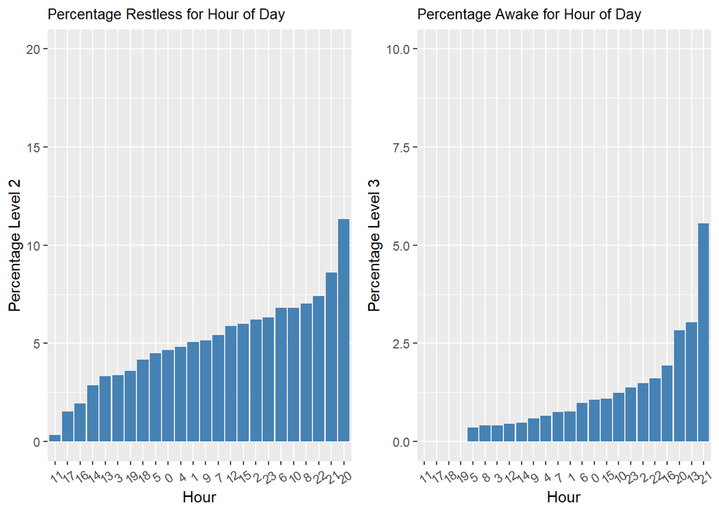

```r
grid.arrange(q3, q4, nrow=1, ncol=2)
```

#### Observations:

- All the days have a similar percentage of Level 1 sleep (93% - 94%). Thursday has the highest and Sunday the lowest, but there’s really not much difference.
- Tuesday has the highest percentage for Level 2 (6% restless) whilst Friday has the lowest at 4.8%.
- Sunday has the highest Level 3 (1.3% awake). This may be related to users’ apprehension for start of the working week on Monday morning. Thursday and Tuesday have the least Level 3 percentage at 0.7%.
- In relation to hours of the day, 11am appears to have the best Level 1 sleep pattern (99.7% asleep) and 5pm is second highest. Further investigation is probably required here as to why this is. Not sure if people are actually sleeping at 5pm in the day. A sample larger than 11 would prevent skewing by one or two individuals. 8pm and 9pm has the lowest percentage of Level 1 sleep although this is probably when people have just gone to bed and just beginning to fall asleep. Understandably this time is also reflected at Level 2 (restless) and Level 3 (awake).
- In general correlation between quality of sleep and intensity/METs, and calories consumed, is low.

#### Opportunities:

- If participants can see their sleep profile - including how much sleep and the quality of that sleep - users could make the necessary adjustments to improve their sleep and overall wellbeing.